# Sharon Walsh - Assignment 5 - ML 64060

Sharon Walsh

2024-03-25

# Summary

- Hierarchical clustering was used to cluster the data. 4 clusters total.
- The following conclusions were obtained based on the averages of each cluster:
- Cluster 1 = High Protein, High Sodium, High Fiber, High Potassium
- Cluster 2 = High Calories, High Fat, High Sodium, High Sugars
- Cluster 3 = High Calories, Med-High Protein, High Sodium, High Carbohydrates
- Cluster 4 = No Fat, No Sodium, No Sugar, High Carbohydrates

Please also note:

- Clusters 2 & 3 each contain 33 cereals each.
- Cluster 1 contains 3 cereals and Cluster 4 contains 5 cereals.
- If consumers are comparing cereals amongst the ones contained in this dataset and desire cereals with high levels of calories, fat, sodium, and sugars (Cluster 2) or cereals with high or med-high levels of calories, protein, sodium, and carbohydrates (Cluster 3), then those consumers have more options since Clusters 2 and 3 each contain 33 cereals.
- Whereas if consumers are comparing cereals amongst the ones contained in this dataset and desire cereals with high levels of protein, sodium, fiber, and potassium (Cluster 1) or cereals with no fat, no sodium, no sugar, and high carbohydrates (Cluster 4), then those consumers have less options since Cluster 1 only contains 3 cereals total and Cluster 4 only contains 5 cereals total.
- Due to the discrepancies in scales and units used to measure nutritional attributes, normalization is highly recommended with very few (if any) exceptions when requested to find a cluster of “healthy” cereals. Additionally “healthy” cereals can be defined many different ways with a variety of nutritional attributes so there is even more reason to normalize all the various nutritional attributes.

# Problem Statement

- The purpose of this assignment is to use Hierarchical Clustering.

The dataset Cereals.csv includes nutritional information, store display, and consumer ratings for 77 breakfast cereals.

```r
setwd("C:/Users/sharo/OneDrive/Documents/ML 2024/Assignment 5")
DF <- read.csv("Cereals.csv")
```

```r
View(DF)
```

```r
library(gridExtra)
library(GGally)
library(factoextra)
library(magrittr)
library(dplyr)
library(tidyverse)
```

Data Preprocessing. Remove all cereals with missing values.

```r
sum(is.na(DF))
```

```
## [1] 4
```

```r
sapply(DF, function(x) sum(is.na(x))) # There is 1 missing value in the carbohydrates attribute. There is 1 missing value in the sugars attribute. There are 2 missing values in the potassium attribute.
```

```
##     name      mfr     type calories  protein      fat   sodium    fiber
##        0        0        0        0        0        0        0        0
##    carbo   sugars   potass vitamins    shelf   weight     cups   rating
##        1        1        2        0        0        0        0        0
```

```r
DF <- na.omit(DF)
```

```r
sum(is.na(DF))
```

```
## [1] 0
```

```r
sapply(DF, function(x) sum(is.na(x))) # Missing values are removed.
```

```
##     name      mfr     type calories  protein      fat   sodium    fiber
##        0        0        0        0        0        0        0        0
##    carbo   sugars   potass vitamins    shelf   weight     cups   rating
##        0        0        0        0        0        0        0        0
```

```r
View(DF)
```

```r
summary(DF)
```

```
##      name               mfr                type              calories
##  Length:74          Length:74          Length:74          Min.   : 50
##  Class :character   Class :character   Class :character   1st Qu.:100
##  Mode  :character   Mode  :character   Mode  :character   Median :110
##                                                           Mean   :107
##                                                           3rd Qu.:110
##                                                           Max.   :160
##     protein           fat        sodium          fiber            carbo
##  Min.   :1.000   Min.   :0   Min.   :  0.0   Min.   : 0.000   Min.   : 5.00
##  1st Qu.:2.000   1st Qu.:0   1st Qu.:135.0   1st Qu.: 0.250   1st Qu.:12.00
##  Median :2.500   Median :1   Median :180.0   Median : 2.000   Median :14.50
##  Mean   :2.514   Mean   :1   Mean   :162.4   Mean   : 2.176   Mean   :14.73
##  3rd Qu.:3.000   3rd Qu.:1   3rd Qu.:217.5   3rd Qu.: 3.000   3rd Qu.:17.00
##  Max.   :6.000   Max.   :5   Max.   :320.0   Max.   :14.000   Max.   :23.00
##      sugars           potass          vitamins          shelf
##  Min.   : 0.000   Min.   : 15.00   Min.   :  0.00   Min.   :1.000
##  1st Qu.: 3.000   1st Qu.: 41.25   1st Qu.: 25.00   1st Qu.:1.250
##  Median : 7.000   Median : 90.00   Median : 25.00   Median :2.000
##  Mean   : 7.108   Mean   : 98.51   Mean   : 29.05   Mean   :2.216
##  3rd Qu.:11.000   3rd Qu.:120.00   3rd Qu.: 25.00   3rd Qu.:3.000
##  Max.   :15.000   Max.   :330.00   Max.   :100.00   Max.   :3.000
##      weight           cups            rating
##  Min.   :0.500   Min.   :0.2500   Min.   :18.04
##  1st Qu.:1.000   1st Qu.:0.6700   1st Qu.:32.45
##  Median :1.000   Median :0.7500   Median :40.25
##  Mean   :1.031   Mean   :0.8216   Mean   :42.37
##  3rd Qu.:1.000   3rd Qu.:1.0000   3rd Qu.:50.52
##  Max.   :1.500   Max.   :1.5000   Max.   :93.70
```

```r
rownames(DF) <- DF$name
```

```r
View(DF)
```

Apply hierarchical clustering to the data using Euclidean distance to the normalized measurements.

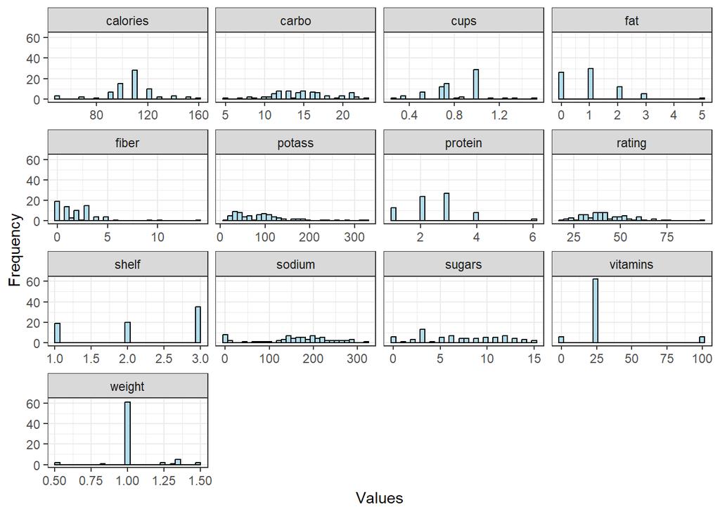

```r
DF %>%
  gather(attributes, value, 4:16) %>%
  ggplot(aes(x = value)) +
  geom_histogram(fill = 'lightblue2', color = 'black') +
  facet_wrap(~attributes, scales = 'free_x') +
  labs(x="Values", y="Frequency") +
  theme_bw()
```

Hierarchical clustering is sensitive to noise and outliers. The following attributes appear to contain outliers: fat, protein, vitamins, fiber, rating.

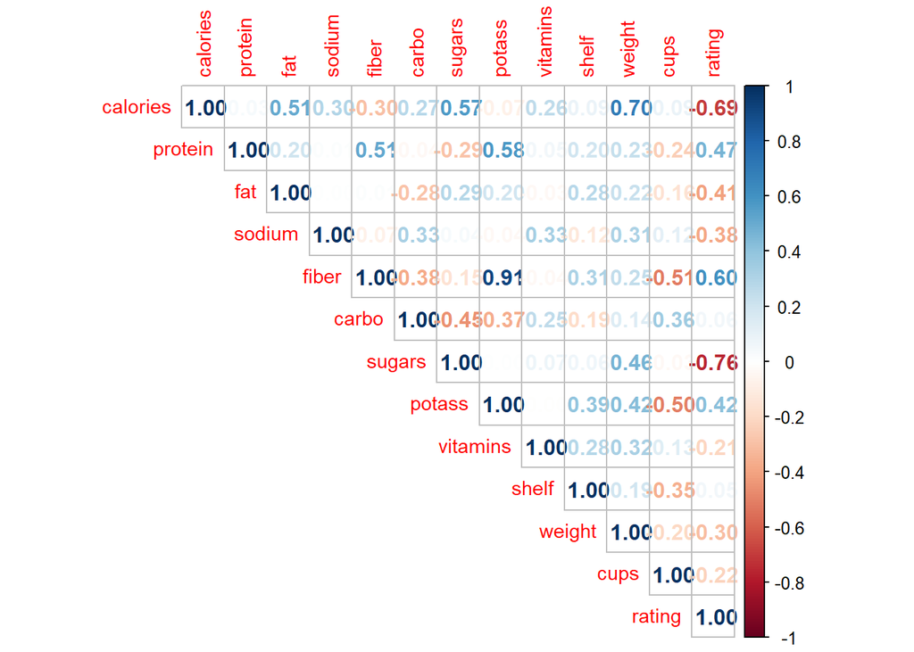

```r
library(corrplot)
corrplot(cor(DF[, c(4:16)]), type = 'upper', method = 'number', tl.cex = 0.9)
```

calories, rating, sugars, fiber

For clarity and succinctness in the analysis, these four attributes will be used.

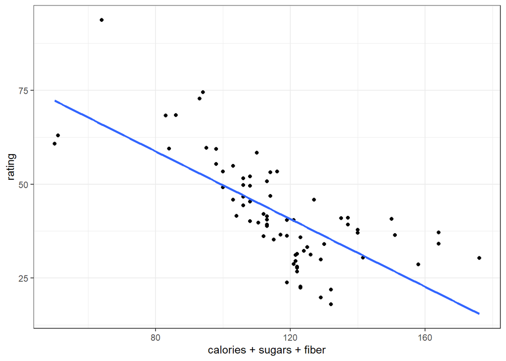

```r
ggplot(DF, aes(x = calories + sugars + fiber, y = rating)) +
  geom_point() +
  geom_smooth(method = 'lm', se = FALSE) +
  theme_bw()
```

Identify outliers from the variables being used for the clustering analysis.

```r
boxplot(DF$fiber, plot=FALSE)$out
```

```
## [1] 10  9 14
```

```r
boxplot(DF$rating, plot=FALSE)$out
```

```
## [1] 93.70491
```

Although these outliers are identified, not enough information is known as to whether it is appropriate to remove them. For the sake of this analysis, the outliers will remain in the dataset.

```r
DF2 <- subset(DF, select = -c(name, mfr, type, protein, fat, sodium, carbo, potass, vitamins,
                              shelf, weight, cups))
```

```r
View(DF2)
```

```r
DF2 <- scale(DF2) #Data is normalized.
```

```r
View(DF2)
```

```r
summary(DF2)
```

```
##     calories           fiber              sugars            rating
##  Min.   :-2.8738   Min.   :-0.89778   Min.   :-1.6306   Min.   :-1.7336
##  1st Qu.:-0.3541   1st Qu.:-0.79462   1st Qu.:-0.9424   1st Qu.:-0.7071
##  Median : 0.1498   Median :-0.07249   Median :-0.0248   Median :-0.1510
##  Mean   : 0.0000   Mean   : 0.00000   Mean   : 0.0000   Mean   : 0.0000
##  3rd Qu.: 0.1498   3rd Qu.: 0.34015   3rd Qu.: 0.8928   3rd Qu.: 0.5807
##  Max.   : 2.6695   Max.   : 4.87925   Max.   : 1.8104   Max.   : 3.6578
```

```r
str(DF2)
```

```
##  num [1:74, 1:4] -1.866 0.654 -1.866 -2.874 0.15 ...
##  - attr(*, "dimnames")=List of 2
##   ..$ : chr [1:74] "100%_Bran" "100%_Natural_Bran" "All-Bran" "All-Bran_with_Extra_Fiber" ...
##   ..$ : chr [1:4] "calories" "fiber" "sugars" "rating"
##  - attr(*, "scaled:center")= Named num [1:4] 107.03 2.18 7.11 42.37
##   ..- attr(*, "names")= chr [1:4] "calories" "fiber" "sugars" "rating"
##  - attr(*, "scaled:scale")= Named num [1:4] 19.84 2.42 4.36 14.03
##   ..- attr(*, "names")= chr [1:4] "calories" "fiber" "sugars" "rating"
```

Apply hierarchical clustering to the data using Euclidean distance to the normalized measurements. Use Agnes to compare the clustering from single linkage, complete linkage, average linkage, and Ward. Choose the best method.

```r
library(stats)
library(cluster)
set.seed(234)
# Dissimilaarity matrix
Dist <- dist(DF2, method = "euclidean")
```

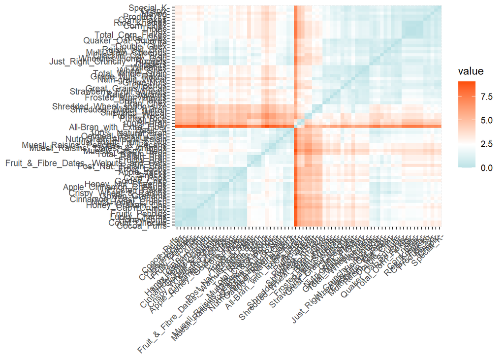

```r
distance <- get_dist(DF2) # Euclidean distance default
fviz_dist(distance, gradient = list(low = "#00AFBB", mid = "white", high = "#FC4E07"))
```

```r
# Compute with agnes and with different linkage methods
Sgl_Linkage <- agnes(Dist, method = "single")
print(Sgl_Linkage$ac)
```

```
## [1] 0.8501709
```

```r
# Compute with agnes and with different linkage methods
Comp_Linkage <- agnes(Dist, method = "complete")
print(Comp_Linkage$ac)
```

```
## [1] 0.9435598
```

```r
# Compute with agnes and with different linkage methods
Avg_Linkage <- agnes(Dist, method = "average")
print(Avg_Linkage$ac)
```

```
## [1] 0.9088615
```

```r
# Compute with agnes and with different linkage methods
Ward_Linkage <- agnes(Dist, method = "ward")
print(Ward_Linkage$ac)
```

```
## [1] 0.9663268
```

The best method is Ward. The Ward Linkage ac is closest to 1 with a result of 0.9663268.

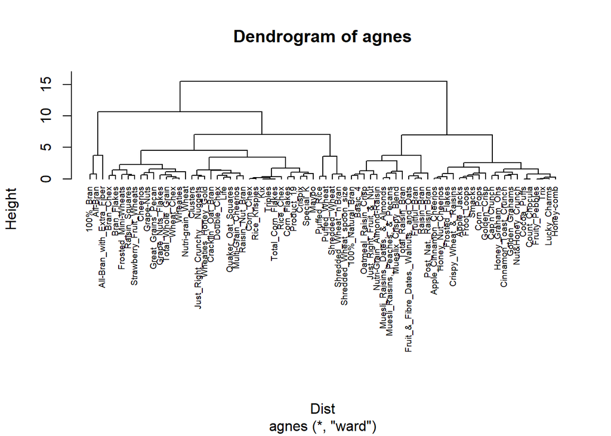

```r
# Plot the obtained dendrogram
pltree(Ward_Linkage, cex = 0.6, hang = -1, main = "Dendrogram of agnes")
```

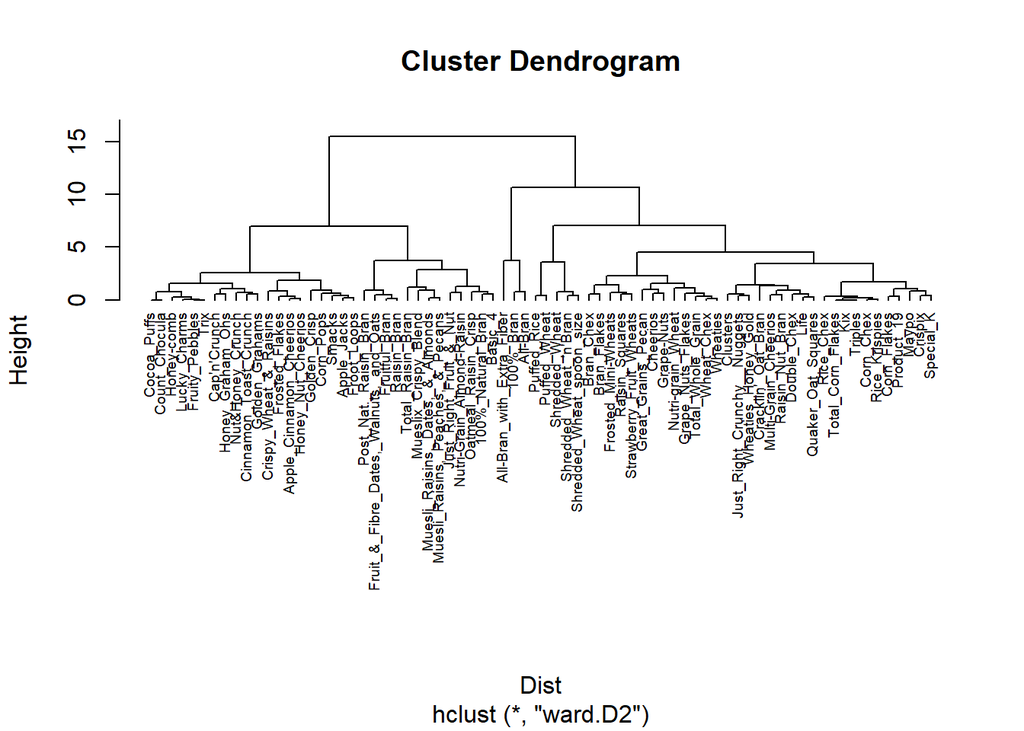

```r
# Hierarchical clustering using Complete Linkage
Ward <- hclust(Dist, method = "ward.D2" )
# Plot the obtained dendrogram
plot(Ward, cex = 0.6, hang = -1)
```

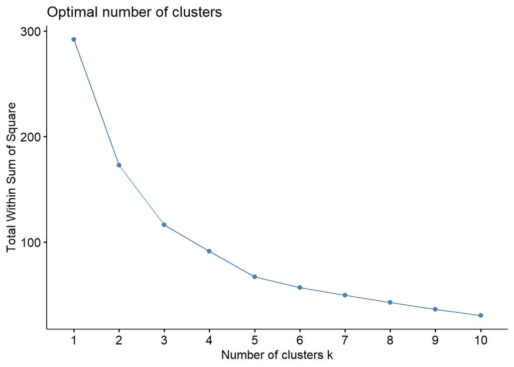

```r
fviz_nbclust(DF2, FUN = hcut, method = "wss") # Elbow Graph
```

```r
Clusters <- cutree(Ward, k = 4) #Clusters based on Ward method and k = 4.
Clusters
```

```
##                              100%_Bran                      100%_Natural_Bran
##                                      1                                      2
##                               All-Bran              All-Bran_with_Extra_Fiber
##                                      1                                      1
##                Apple_Cinnamon_Cheerios                            Apple_Jacks
##                                      2                                      2
##                                Basic_4                              Bran_Chex
##                                      2                                      3
##                            Bran_Flakes                           Cap'n'Crunch
##                                      3                                      2
##                               Cheerios                  Cinnamon_Toast_Crunch
##                                      3                                      2
##                               Clusters                            Cocoa_Puffs
##                                      3                                      2
##                              Corn_Chex                            Corn_Flakes
##                                      3                                      3
##                              Corn_Pops                          Count_Chocula
##                                      2                                      2
##                     Cracklin'_Oat_Bran                                Crispix
##                                      3                                      3
##                 Crispy_Wheat_&_Raisins                            Double_Chex
##                                      2                                      3
##                            Froot_Loops                         Frosted_Flakes
##                                      2                                      2
##                    Frosted_Mini-Wheats Fruit_&_Fibre_Dates,_Walnuts,_and_Oats
##                                      3                                      2
##                          Fruitful_Bran                         Fruity_Pebbles
##                                      2                                      2
##                           Golden_Crisp                         Golden_Grahams
##                                      2                                      2
##                      Grape_Nuts_Flakes                             Grape-Nuts
##                                      3                                      3
##                     Great_Grains_Pecan                       Honey_Graham_Ohs
##                                      3                                      2
##                     Honey_Nut_Cheerios                             Honey-comb
##                                      2                                      2
##            Just_Right_Crunchy__Nuggets                 Just_Right_Fruit_&_Nut
##                                      3                                      2
##                                    Kix                                   Life
##                                      3                                      3
```

[output cut: 19 more lines]

```
##                                      3                                      3
##                         Shredded_Wheat                 Shredded_Wheat_'n'Bran
##                                      4                                      4
##              Shredded_Wheat_spoon_size                                 Smacks
##                                      4                                      2
##                              Special_K                Strawberry_Fruit_Wheats
##                                      3                                      3
##                      Total_Corn_Flakes                      Total_Raisin_Bran
##                                      3                                      2
##                      Total_Whole_Grain                                Triples
##                                      3                                      3
##                                   Trix                             Wheat_Chex
##                                      2                                      3
##                               Wheaties                    Wheaties_Honey_Gold
##                                      3                                      3
```

```r
Clusters_Print <- function(labels, k) {
  for (i in 1:k) {
    print(paste("cluster", i))
    print(DF2[labels==i, c("calories", "fiber","sugars", "rating")])
  }
}
```

```r
Clusters_Print(Clusters, 4)
```

```
## [1] "cluster 1"
##                            calories    fiber     sugars   rating
## 100%_Bran                 -1.865915 3.228667 -0.2542051 1.854904
## All-Bran                  -1.865915 2.816023 -0.4836096 1.215196
## All-Bran_with_Extra_Fiber -2.873782 4.879247 -1.6306324 3.657844
## [1] "cluster 2"
##                                          calories       fiber      sugars
## 100%_Natural_Bran                       0.6537514 -0.07249167  0.20460407
## Apple_Cinnamon_Cheerios                 0.1498180 -0.27881412  0.66341318
## Apple_Jacks                             0.1498180 -0.48513656  1.58103142
## Basic_4                                 1.1576848 -0.07249167  0.20460407
## Cap'n'Crunch                            0.6537514 -0.89778146  1.12222230
## Cinnamon_Toast_Crunch                   0.6537514 -0.89778146  0.43400862
## Cocoa_Puffs                             0.1498180 -0.89778146  1.35162686
## Corn_Pops                               0.1498180 -0.48513656  1.12222230
## Count_Chocula                           0.1498180 -0.89778146  1.35162686
## Crispy_Wheat_&_Raisins                 -0.3541153 -0.07249167  0.66341318
## Froot_Loops                             0.1498180 -0.48513656  1.35162686
## Frosted_Flakes                          0.1498180 -0.48513656  0.89281774
## Fruit_&_Fibre_Dates,_Walnuts,_and_Oats  0.6537514  1.16544301  0.66341318
## Fruitful_Bran                           0.6537514  1.16544301  1.12222230
## Fruity_Pebbles                          0.1498180 -0.89778146  1.12222230
## Golden_Crisp                           -0.3541153 -0.89778146  1.81043598
## Golden_Grahams                          0.1498180 -0.89778146  0.43400862
## Honey_Graham_Ohs                        0.6537514 -0.48513656  0.89281774
## Honey_Nut_Cheerios                      0.1498180 -0.27881412  0.66341318
## Honey-comb                              0.1498180 -0.89778146  0.89281774
## Just_Right_Fruit_&_Nut                  1.6616182 -0.07249167  0.43400862
## Lucky_Charms                            0.1498180 -0.89778146  1.12222230
## Muesli_Raisins,_Dates,_&_Almonds        2.1655516  0.34015322  0.89281774
## Muesli_Raisins,_Peaches,_&_Pecans       2.1655516  0.34015322  0.89281774
## Mueslix_Crispy_Blend                    2.6694849  0.34015322  1.35162686
## Nut&Honey_Crunch                        0.6537514 -0.89778146  0.43400862
## Nutri-Grain_Almond-Raisin               1.6616182  0.34015322 -0.02480049
## Oatmeal_Raisin_Crisp                    1.1576848 -0.27881412  0.66341318
## Post_Nat._Raisin_Bran                   0.6537514  1.57808790  1.58103142
## Raisin_Bran                             0.6537514  1.16544301  1.12222230
## Smacks                                  0.1498180 -0.48513656  1.81043598
## Total_Raisin_Bran                       1.6616182  0.75279812  1.58103142
## Trix                                    0.1498180 -0.89778146  1.12222230
```

[output cut: 61 more lines]

```
## Special_K                    0.1498180 -0.48513656 -0.94241873  0.76669214
## Strawberry_Fruit_Wheats     -0.8580487  0.34015322 -0.48360961  1.21081332
## Total_Corn_Flakes            0.1498180 -0.89778146 -0.94241873 -0.25168258
## Total_Whole_Grain           -0.3541153  0.34015322 -0.94241873  0.30548275
## Triples                      0.1498180 -0.89778146 -0.94241873 -0.23269772
## Wheat_Chex                  -0.3541153  0.34015322 -0.94241873  0.52841741
## Wheaties                    -0.3541153  0.34015322 -0.94241873  0.65701831
## Wheaties_Honey_Gold          0.1498180 -0.48513656  0.20460407 -0.44066942
## [1] "cluster 4"
##                             calories      fiber    sugars   rating
## Puffed_Rice               -2.8737823 -0.8977815 -1.630632 1.310012
## Puffed_Wheat              -2.8737823 -0.4851366 -1.630632 1.470306
## Shredded_Wheat            -1.3619821  0.3401532 -1.630632 1.842998
## Shredded_Wheat_'n'Bran    -0.8580487  0.7527981 -1.630632 2.287432
## Shredded_Wheat_spoon_size -0.8580487  0.3401532 -1.630632 2.168350
```

```r
aggregate(DF2, by = list(Clusters), FUN = mean)#Average of calories, fiber, sugars, and rating by cluster.
```

```
##   Group.1   calories       fiber     sugars     rating
## 1       1 -2.2018711  3.64131237 -0.7894824  2.2426479
## 2       2  0.6537514 -0.20378777  0.9553826 -0.7875431
## 3       3 -0.1861376 -0.12876143 -0.6365460  0.3085419
## 4       4 -1.7651288  0.01003731 -1.6306324  1.8158195
```

```r
C <-as.data.frame(cbind(DF2, Clusters))
nrow(C)
```

```
## [1] 74
```

```r
Centroids <- colMeans (C[C$Clusters ,]) #Centroids of each attribute used for analysis across clusters.
Centroids
```

```
##   calories      fiber     sugars     rating   Clusters
## -0.8103794  1.6840373 -0.2449049  0.5977154  1.4459459
```

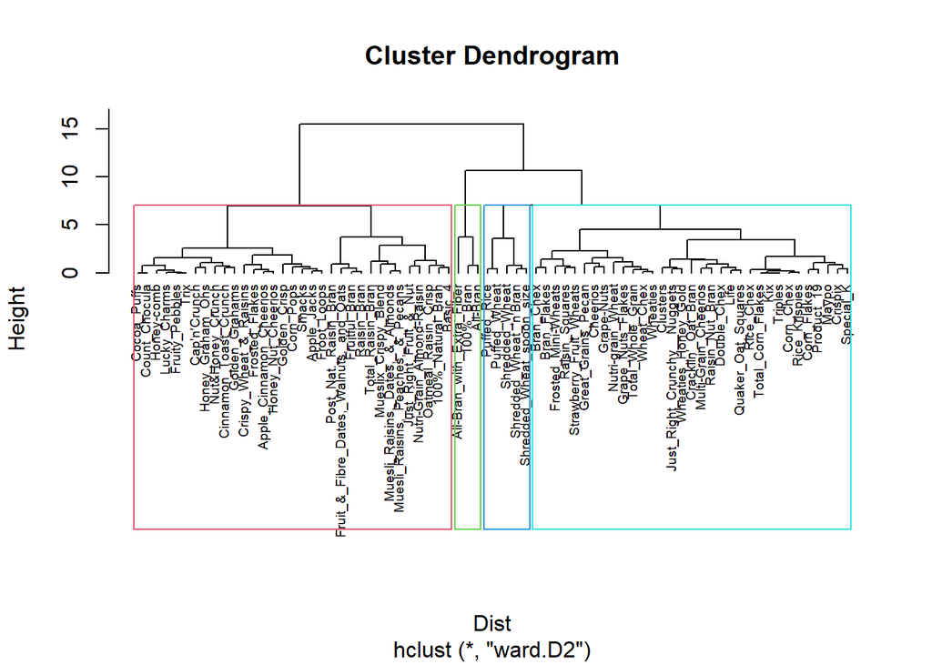

```r
plot(Ward, cex = 0.6, hang = -1)
rect.hclust(Ward, k = 4, border = 2:5) #Visualization of the 4 clusters in the dendrogram.
```

```r
table(Clusters) # Clusters 2 & 3 each contain approximately 45% of the observations. Clusters 1 and 4 contain approximately 4% & 6% of the observations respectively.
```

```
## Clusters
##  1  2  3  4
##  3 33 33  5
```

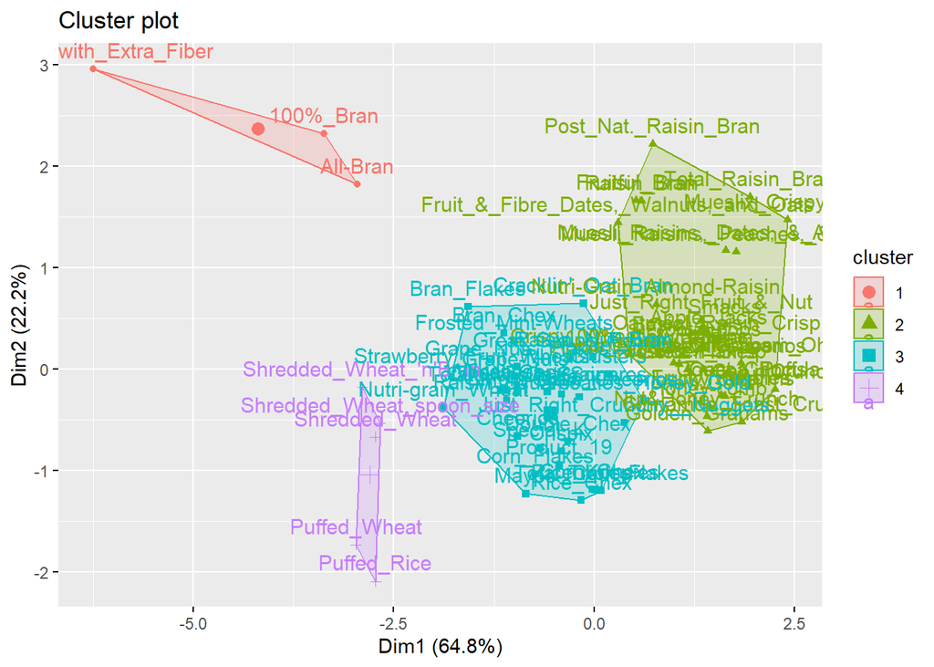

```r
fviz_cluster(list(data = DF2, cluster = Clusters)) # Visualization of the 4 clusters.
```

```r
dd <- cbind(DF, cluster = Clusters)
head(dd)
```

```
##                                                name mfr type calories protein
## 100%_Bran                                 100%_Bran   N    C       70       4
## 100%_Natural_Bran                 100%_Natural_Bran   Q    C      120       3
## All-Bran                                   All-Bran   K    C       70       4
## All-Bran_with_Extra_Fiber All-Bran_with_Extra_Fiber   K    C       50       4
## Apple_Cinnamon_Cheerios     Apple_Cinnamon_Cheerios   G    C      110       2
## Apple_Jacks                             Apple_Jacks   K    C      110       2
##                           fat sodium fiber carbo sugars potass vitamins shelf
## 100%_Bran                   1    130  10.0   5.0      6    280       25     3
## 100%_Natural_Bran           5     15   2.0   8.0      8    135        0     3
## All-Bran                    1    260   9.0   7.0      5    320       25     3
## All-Bran_with_Extra_Fiber   0    140  14.0   8.0      0    330       25     3
## Apple_Cinnamon_Cheerios     2    180   1.5  10.5     10     70       25     1
## Apple_Jacks                 0    125   1.0  11.0     14     30       25     2
##                           weight cups   rating cluster
## 100%_Bran                      1 0.33 68.40297       1
## 100%_Natural_Bran              1 1.00 33.98368       2
## All-Bran                       1 0.33 59.42551       1
## All-Bran_with_Extra_Fiber      1 0.50 93.70491       1
## Apple_Cinnamon_Cheerios        1 0.75 29.50954       2
## Apple_Jacks                    1 1.00 33.17409       2
```

```r
View(dd)
```

```r
DT::datatable(dd[, -1], class = 'cell-border stripe', options = list(autoWidth = TRUE, pageLength = 74))
```

|  | mfr | type | calories | protein | fat | sodium | fiber | carbo | sugars | potass | vitamins | shelf | weight | cups | rating | cluster |
| --- | --- | --- | --- | --- | --- | --- | --- | --- | --- | --- | --- | --- | --- | --- | --- | --- |
| 100%_Bran | N | C | 70 | 4 | 1 | 130 | 10 | 5 | 6 | 280 | 25 | 3 | 1 | 0.33 | 68.402973 | 1 |
| 100%_Natural_Bran | Q | C | 120 | 3 | 5 | 15 | 2 | 8 | 8 | 135 | 0 | 3 | 1 | 1 | 33.983679 | 2 |
| All-Bran | K | C | 70 | 4 | 1 | 260 | 9 | 7 | 5 | 320 | 25 | 3 | 1 | 0.33 | 59.425505 | 1 |
| All-Bran_with_Extra_Fiber | K | C | 50 | 4 | 0 | 140 | 14 | 8 | 0 | 330 | 25 | 3 | 1 | 0.5 | 93.704912 | 1 |
| Apple_Cinnamon_Cheerios | G | C | 110 | 2 | 2 | 180 | 1.5 | 10.5 | 10 | 70 | 25 | 1 | 1 | 0.75 | 29.509541 | 2 |
| Apple_Jacks | K | C | 110 | 2 | 0 | 125 | 1 | 11 | 14 | 30 | 25 | 2 | 1 | 1 | 33.174094 | 2 |
| Basic_4 | G | C | 130 | 3 | 2 | 210 | 2 | 18 | 8 | 100 | 25 | 3 | 1.33 | 0.75 | 37.038562 | 2 |
| Bran_Chex | R | C | 90 | 2 | 1 | 200 | 4 | 15 | 6 | 125 | 25 | 1 | 1 | 0.67 | 49.120253 | 3 |
| Bran_Flakes | P | C | 90 | 3 | 0 | 210 | 5 | 13 | 5 | 190 | 25 | 3 | 1 | 0.67 | 53.313813 | 3 |
| Cap'n'Crunch | Q | C | 120 | 1 | 2 | 220 | 0 | 12 | 12 | 35 | 25 | 2 | 1 | 0.75 | 18.042851 | 2 |

[output cut: 64 more lines]

```r
DD <- (dd[, c( 16:17)])
DD
```

```
##                                          rating cluster
## 100%_Bran                              68.40297       1
## 100%_Natural_Bran                      33.98368       2
## All-Bran                               59.42551       1
## All-Bran_with_Extra_Fiber              93.70491       1
## Apple_Cinnamon_Cheerios                29.50954       2
## Apple_Jacks                            33.17409       2
## Basic_4                                37.03856       2
## Bran_Chex                              49.12025       3
## Bran_Flakes                            53.31381       3
## Cap'n'Crunch                           18.04285       2
## Cheerios                               50.76500       3
## Cinnamon_Toast_Crunch                  19.82357       2
## Clusters                               40.40021       3
## Cocoa_Puffs                            22.73645       2
## Corn_Chex                              41.44502       3
## Corn_Flakes                            45.86332       3
## Corn_Pops                              35.78279       2
## Count_Chocula                          22.39651       2
## Cracklin'_Oat_Bran                     40.44877       3
## Crispix                                46.89564       3
## Crispy_Wheat_&_Raisins                 36.17620       2
## Double_Chex                            44.33086       3
## Froot_Loops                            32.20758       2
## Frosted_Flakes                         31.43597       2
## Frosted_Mini-Wheats                    58.34514       3
## Fruit_&_Fibre_Dates,_Walnuts,_and_Oats 40.91705       2
## Fruitful_Bran                          41.01549       2
## Fruity_Pebbles                         28.02576       2
## Golden_Crisp                           35.25244       2
## Golden_Grahams                         23.80404       2
## Grape_Nuts_Flakes                      52.07690       3
## Grape-Nuts                             53.37101       3
## Great_Grains_Pecan                     45.81172       3
## Honey_Graham_Ohs                       21.87129       2
## Honey_Nut_Cheerios                     31.07222       2
## Honey-comb                             28.74241       2
## Just_Right_Crunchy__Nuggets            36.52368       3
## Just_Right_Fruit_&_Nut                 36.47151       2
## Kix                                    39.24111       3
```

[output cut: 20 more lines]

```
## Rice_Krispies                          40.56016       3
## Shredded_Wheat                         68.23588       4
## Shredded_Wheat_'n'Bran                 74.47295       4
## Shredded_Wheat_spoon_size              72.80179       4
## Smacks                                 31.23005       2
## Special_K                              53.13132       3
## Strawberry_Fruit_Wheats                59.36399       3
## Total_Corn_Flakes                      38.83975       3
## Total_Raisin_Bran                      28.59278       2
## Total_Whole_Grain                      46.65884       3
## Triples                                39.10617       3
## Trix                                   27.75330       2
## Wheat_Chex                             49.78744       3
## Wheaties                               51.59219       3
## Wheaties_Honey_Gold                    36.18756       3
```

```r
DT::datatable(DD, class = 'cell-border stripe', options = list(autoWidth = TRUE, pageLength = 74))
```

|  | rating | cluster |
| --- | --- | --- |
| 100%_Bran | 68.402973 | 1 |
| 100%_Natural_Bran | 33.983679 | 2 |
| All-Bran | 59.425505 | 1 |
| All-Bran_with_Extra_Fiber | 93.704912 | 1 |
| Apple_Cinnamon_Cheerios | 29.509541 | 2 |
| Apple_Jacks | 33.174094 | 2 |
| Basic_4 | 37.038562 | 2 |
| Bran_Chex | 49.120253 | 3 |
| Bran_Flakes | 53.313813 | 3 |
| Cap'n'Crunch | 18.042851 | 2 |

[output cut: 64 more lines]

```r
DD_Manu <- subset(dd, select = -c(name, type, calories, protein, fat, sodium,fiber,
                                  carbo, sugars, potass, vitamins,
                              shelf, weight, cups, rating))
DD_Manu
```

```
##                                        mfr cluster
## 100%_Bran                                N       1
## 100%_Natural_Bran                        Q       2
## All-Bran                                 K       1
## All-Bran_with_Extra_Fiber                K       1
## Apple_Cinnamon_Cheerios                  G       2
## Apple_Jacks                              K       2
## Basic_4                                  G       2
## Bran_Chex                                R       3
## Bran_Flakes                              P       3
## Cap'n'Crunch                             Q       2
## Cheerios                                 G       3
## Cinnamon_Toast_Crunch                    G       2
## Clusters                                 G       3
## Cocoa_Puffs                              G       2
## Corn_Chex                                R       3
## Corn_Flakes                              K       3
## Corn_Pops                                K       2
## Count_Chocula                            G       2
## Cracklin'_Oat_Bran                       K       3
## Crispix                                  K       3
## Crispy_Wheat_&_Raisins                   G       2
## Double_Chex                              R       3
## Froot_Loops                              K       2
## Frosted_Flakes                           K       2
## Frosted_Mini-Wheats                      K       3
## Fruit_&_Fibre_Dates,_Walnuts,_and_Oats   P       2
## Fruitful_Bran                            K       2
## Fruity_Pebbles                           P       2
## Golden_Crisp                             P       2
## Golden_Grahams                           G       2
## Grape_Nuts_Flakes                        P       3
## Grape-Nuts                               P       3
## Great_Grains_Pecan                       P       3
## Honey_Graham_Ohs                         Q       2
## Honey_Nut_Cheerios                       G       2
## Honey-comb                               P       2
## Just_Right_Crunchy__Nuggets              K       3
## Just_Right_Fruit_&_Nut                   K       2
## Kix                                      G       3
```

[output cut: 20 more lines]

```
## Rice_Krispies                            K       3
## Shredded_Wheat                           N       4
## Shredded_Wheat_'n'Bran                   N       4
## Shredded_Wheat_spoon_size                N       4
## Smacks                                   K       2
## Special_K                                K       3
## Strawberry_Fruit_Wheats                  N       3
## Total_Corn_Flakes                        G       3
## Total_Raisin_Bran                        G       2
## Total_Whole_Grain                        G       3
## Triples                                  G       3
## Trix                                     G       2
## Wheat_Chex                               R       3
## Wheaties                                 G       3
## Wheaties_Honey_Gold                      G       3
```

```r
View(DD_Manu)
```

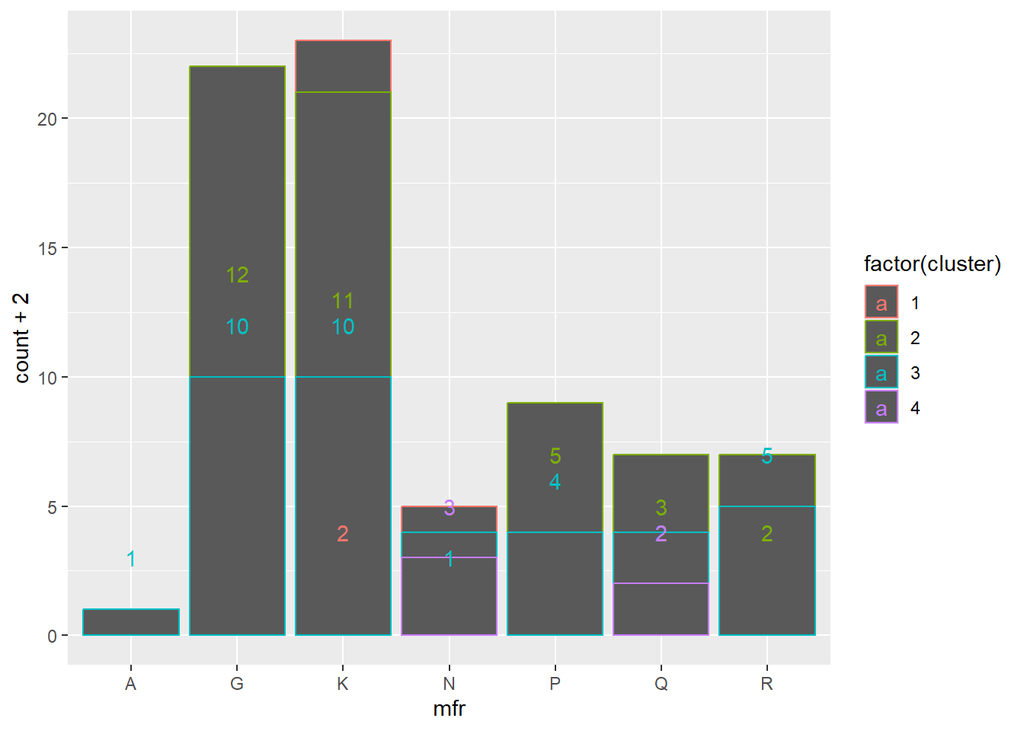

```r
ggplot(DD_Manu, aes(mfr, colour = factor(cluster))) +
  geom_bar() +
  geom_text(
    aes(
      y = after_stat(count + 2),
      label = after_stat(count)
    ),
    stat = "count"
  )
```

- Clusters by Cereal Manufacturer:

A = American Home Food Products G = General Mills K = Kelloggs N = Nabisco P = Post Q = Quaker Oats R = Ralston Purina

- Cluster 1 consists of cereals from the following manufacturers: K = Kelloggs N = Nabisco
- Cluster 2 consists of cereals from the following manufacturers: G = General Mills K = Kelloggs P = Post Q = Quaker Oats R = Ralston Purina
- Cluster 3 consists of cereals from the following manufacturers: A = American Home Food Products G = General Mills K = Kelloggs N = Nabisco P = Post Q = Quaker Oats R = Ralston Purina
- Cluster 4 consists of cereals from the following manufacturers: N = Nabisco Q = Quaker Oats

```r
Cereals <- as.data.frame(cbind(DF, Clusters))
View(Cereals)
```

```r
Cereals_sort <- Cereals[order(Cereals$Clusters), c(1,17) ]
View(Cereals_sort)
```

```r
Cereals_number <- Cereals_sort%>%group_by(Clusters)%>%summarise(count = n())
print(Cereals_number)
```

```
## # A tibble: 4 × 2
##   Clusters count
##      <int> <int>
## 1        1     3
## 2        2    33
## 3        3    33
## 4        4     5
```

```r
Cereals2 <- Cereals [,4:17]
Table_clusters <- Cereals2 %>% group_by(Clusters) %>% summarize(across(.cols = everything(), .fns = mean))
print(Table_clusters) #Average of all numerical attributes by cluster.
```

```
## # A tibble: 4 × 14
##   Clusters calories protein   fat sodium fiber carbo sugars potass vitamins
##      <int>    <dbl>   <dbl> <dbl>  <dbl> <dbl> <dbl>  <dbl>  <dbl>    <dbl>
## 1        1     63.3    4    0.667   177. 11     6.67   3.67    310     25
## 2        2    120      2.15 1.36    167.  1.68 13.3   11.3      95     28.8
## 3        3    103.     2.79 0.818   181.  1.86 16.7    4.33     85     34.1
## 4        4     72      2.2  0         0   2.2  15.6    0        84      0
## # ℹ 4 more variables: shelf <dbl>, weight <dbl>, cups <dbl>, rating <dbl>
```

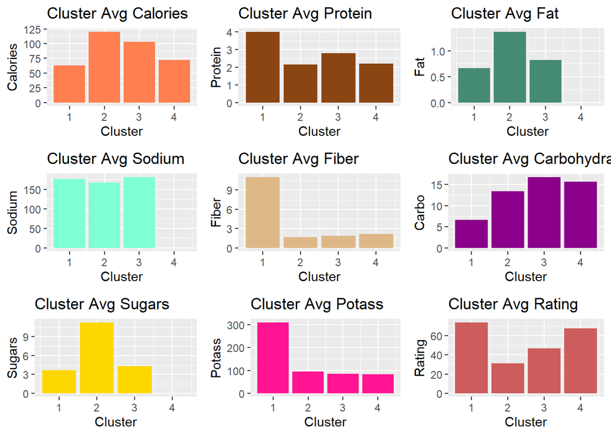

```r
library(cowplot)
calories <- ggplot(Table_clusters, aes(x = Clusters, y = calories)) +
  geom_bar(stat = "identity", fill = "coral") +
  labs(x = "Cluster", y = "Calories") +
  ggtitle("Cluster Avg Calories")

protein <- ggplot(Table_clusters, aes(x = Clusters, y = protein)) +
  geom_bar(stat = "identity", fill = "chocolate4") +
  labs(x = "Cluster", y = "Protein") +
  ggtitle("Cluster Avg Protein")

fat <- ggplot(Table_clusters, aes(x = Clusters, y = fat)) +
  geom_bar(stat = "identity", fill = "aquamarine4") +
  labs(x = "Cluster", y = "Fat") +
  ggtitle("Cluster Avg Fat")

sodium <- ggplot(Table_clusters, aes(x = Clusters, y = sodium)) +
  geom_bar(stat = "identity", fill = "aquamarine") +
  labs(x = "Cluster", y = "Sodium") +
  ggtitle("Cluster Avg Sodium")

fiber <- ggplot(Table_clusters, aes(x = Clusters, y = fiber)) +
  geom_bar(stat = "identity", fill = "burlywood") +
  labs(x = "Cluster", y = "Fiber") +
  ggtitle("Cluster Avg Fiber")

carbo <- ggplot(Table_clusters, aes(x = Clusters, y = carbo)) +
  geom_bar(stat = "identity", fill = "darkmagenta") +
  labs(x = "Cluster", y = "Carbo") +
  ggtitle("Cluster Avg Carbohydrates")

sugars <- ggplot(Table_clusters, aes(x = Clusters, y = sugars)) +
  geom_bar(stat = "identity", fill = "gold") +
  labs(x = "Cluster", y = "Sugars") +
  ggtitle("Cluster Avg Sugars")

potass <- ggplot(Table_clusters, aes(x = Clusters, y = potass)) +
  geom_bar(stat = "identity", fill = "deeppink1") +
  labs(x = "Cluster", y = "Potass") +
  ggtitle("Cluster Avg Potass")

rating <- ggplot(Table_clusters, aes(x = Clusters, y = rating)) +
  geom_bar(stat = "identity", fill = "indianred") +
  labs(x = "Cluster", y = "Rating") +
  ggtitle("Cluster Avg Rating")

plot_grid(calories, protein, fat, sodium, fiber, carbo, sugars, potass, rating)
```

- Highest calories on average: Cluster 2
- Highest protein on average: Cluster 1
- Highest fat on average: Cluster 2
- Highest sodium on average: Cluster 3
- Highest fiber on average: Cluster 1
- Highest carbohydrates on average: Cluster 3
- Highest sugar on average: Cluster 2
- Highest potassium on average: Cluster 1
- Highest rating on average: Cluster 1

```r
Cluster_1_Table <- c("Lowest","Highest","Highest","Very High","Highest", "Lowest","Lowest","Highest",
                     "Highest")
Cluster_2_Table <- c("Highest","Lowest","Lowest","Very High","Lowest","Med-Low", "Highest",
                     "Very Low","Lowest")
Cluster_3_Table <- c("Med-High","Average","Average","Highest","Med-Low","Highest","Very Low",
                     "Very Low", "Average")
Cluster_4_Table <- c("Average","Average","None","None","Med-Low","Very High","None","Lowest",
                     "Med-High")
Analysis <- data.frame(Cluster_1 = Cluster_1_Table, Cluster_2 = Cluster_2_Table,
                       Cluster_3 = Cluster_3_Table,Cluster_4_Table,
                       row.names = c('Calories', 'Protein', 'Fat', 'Sodium', 'Fiber', 'Carbohydrates',
                                     'Sugars', 'Potassium', 'Rating'))
print(Analysis)
```

[output not shown]

```r
Cluster_1_Summary <- c("High Protein", "High Sodium", "High Fiber", "High Potassium")
Cluster_2_Summary <- c("High Calories", "High Fat", "High Sodium", "High Sugars")
Cluster_3_Summary <- c("High Calories", "Med-High Protein", "High Sodium", "High Carbohydrates")
Cluster_4_Summary <- c("No Fat", "No Sodium", "No Sugar", "High Carbohydrates")
Analysis2 <- data.frame(Cluster_1 = Cluster_1_Summary, Cluster_2 = Cluster_2_Summary,
                       Cluster_3 = Cluster_3_Summary,Cluster_4 = Cluster_4_Summary
                       )
print(Analysis2)
```

```
##        Cluster_1     Cluster_2          Cluster_3          Cluster_4
## 1   High Protein High Calories      High Calories             No Fat
## 2    High Sodium      High Fat   Med-High Protein          No Sodium
## 3     High Fiber   High Sodium        High Sodium           No Sugar
## 4 High Potassium   High Sugars High Carbohydrates High Carbohydrates
```

- The following conclusions were obtained based on the averages of each cluster:
- Cluster 1 = High Protein, High Sodium, High Fiber, High Potassium
- Cluster 2 = High Calories, High Fat, High Sodium, High Sugars
- Cluster 3 = High Calories, Med-High Protein, High Sodium, High Carbohydrates
- Cluster 4 = No Fat, No Sodium, No Sugar, High Carbohydrates

Please also note:

- Clusters 2 & 3 each contain 33 cereals each.
- Cluster 1 contains 3 cereals and Cluster 4 contains 5 cereals.
- If consumers are comparing cereals amongst the ones contained in this dataset and desire cereals with high levels of calories, fat, sodium, and sugars (Cluster 2) or cereals with high or med-high levels of calories, protein, sodium, and carbohydrates (Cluster 3), then those consumers have more options since Clusters 2 and 3 each contain 33 cereals.
- Whereas if consumers are comparing cereals amongst the ones contained in this dataset and desire cereals with high levels of protein, sodium, fiber, and potassium (Cluster 1) or cereals with no fat, no sodium, no sugar, and high carbohydrates (Cluster 4), then those consumers have less options since Cluster 1 only contains 3 cereals total and Cluster 4 only contains 5 cereals total.

Comment on the structure of the clusters and on their stability. Hint: To check stability, partition the data and see how well clusters formed based on one part apply to the other part.

Per Dr. Ardakani’s instructions, this question is left unanswered.

The elementary public schools would like to choose a set of cereals to include in their daily cafeterias. Every day a different cereal is offered, but all cereals should support a healthy diet. For this goal, you are requested to find a cluster of “healthy cereals.” Should the data be normalized? If not, how should they be used in the cluster analysis?

Yes, with very few (if any) exceptions, the data should be normalized. “Healthy cereals” can be defined in many ways and nutritional attributes (fiber, sugars, calories, etc.) have many different scales and units. Because clustering is based off of distances between the data points in order to cluster, if the variables are of different scaling or unit measurements, then the largest number (even if not the largest in comparison when scaled) will out-weigh all other attributes.

Furthermore, hierarchical clustering is very sensitive to outliers and noise. If the data is not normalized, the results run a risk of being misleading and inaccurate.

Additionally, many clustering methods used to cluster cereals into groups such as “healthy cereals” rely on distance as the way to assign the cereals to a cluster. If the variables are normalized then the each of the variables is given equal weight when assigned to a cluster. However, if the variables are not normalized then the variables are given unequal weight due to the discrepancies in scales and units used to measure nutritional attributes.